# Ford GoBike Exploration

## Dataset Overview

duration_sec int

start_time object

end_time object

start_station_id float64

start_station_name object

start_station_latitude float64

start_station_longitude float64

end_station_id float64

end_station_name object

end_station_latitude float64

end_station_longitude float64

bike_id int64

user_type object

member_birth_year float64

member_gender object

## Distribution of Trip Duration

In this visualization, we will be looking at the distribution of the trip.

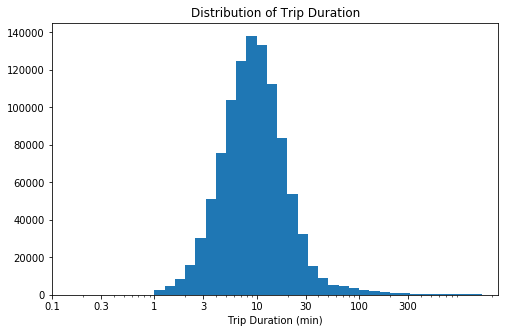

Looking at the distribution from the plot we can see that it is unimodal distribution with an peak at 10 minutes.

## Trip duration based on user type

> Suscriber tends to drive lesser than customer.Suscriber might be using it for regaular use like for work, school. While customer might be tourist or a person who owns car.

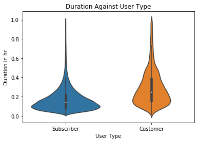

## Trip duration based on gender and age.

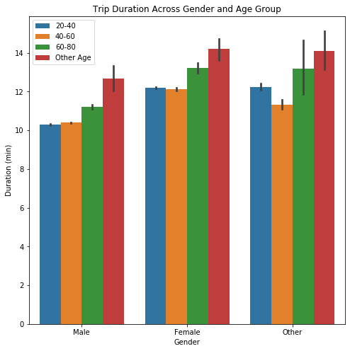